# Day 9: Statistical Learning — In-Class Activity (Solutions)

When does a better fit make a worse model?

Instructor

```r
data(Wage)
```

## Part 1: Training Error vs. Test Error

### Task 1.1: Split the data

```r
set.seed(313)
train_rows <- sample(nrow(Wage), 100)
wage_train <- Wage[train_rows, ]
wage_test  <- Wage[-train_rows, ]

nrow(wage_train)
```

```
## [1] 100
```

```r
nrow(wage_test)
```

```
## [1] 2900
```

### Task 1.2: Write an MSE function

The same pattern as `average_gap()`, but square the gaps before averaging.

```r
mse <- function(actual, predicted) {
  mean((actual - predicted)^2)
}

mse(c(1, 2, 3), c(1, 2, 3))   # should be 0
```

```
## [1] 0
```

```r
mse(c(1, 2, 3), c(2, 3, 4))   # should be 1
```

```
## [1] 1
```

```r
mse(c(1, 2, 3), c(2, 2, 2))   # should be 0.6667
```

```
## [1] 0.6666667
```

The third check is the one that matters. Writing `mean(actual - predicted)^2` squares the *average* gap instead of averaging the squared gaps. That passes the first two checks (every gap there is the same), but here the gaps are −1, 0 and 1, which cancel to an average of 0. Square first, then average.

### Task 1.3: Score one model two ways

```r
fit1 <- lm(wage ~ age, data = wage_train)

train_mse_1 <- mse(wage_train$wage, predict(fit1, newdata = wage_train))
test_mse_1  <- mse(wage_test$wage,  predict(fit1, newdata = wage_test))
train_mse_1
```

```
## [1] 1656.944
```

```r
test_mse_1
```

```
## [1] 1701.856
```

*Which MSE is lower? Why would you expect that?*

Training MSE (1657) is lower than test MSE (1702). `lm()` picks the line that minimizes squared error **on the training data**, so it is tuned to those 100 workers, quirks included. The test workers had no say in where the line went, so it fits them worse on average. (With a single random split this isn’t guaranteed — an unlucky draw can reverse it — but it’s what to expect.)

## Part 2: Turn Up the Flexibility

### Task 2.1: Degrees 1 through 10

```r
errors <- tibble(degree = 1:10, training = NA, test = NA)

for (d in 1:10) {
  fit <- lm(wage ~ poly(age, d), data = wage_train)
  errors$training[d] <- mse(wage_train$wage, predict(fit, newdata = wage_train))
  errors$test[d]     <- mse(wage_test$wage,  predict(fit, newdata = wage_test))
}

errors
```

```
## # A tibble: 10 × 3
##    degree training  test
##     <int>    <dbl> <dbl>
##  1      1    1657. 1702.
##  2      2    1563. 1611.
##  3      3    1560. 1607.
##  4      4    1560. 1609.
##  5      5    1533. 1642.
##  6      6    1518. 1660.
##  7      7    1507. 1665.
##  8      8    1506. 1665.
##  9      9    1503. 1681.
## 10     10    1499. 1871.
```

### Task 2.2: Plot it

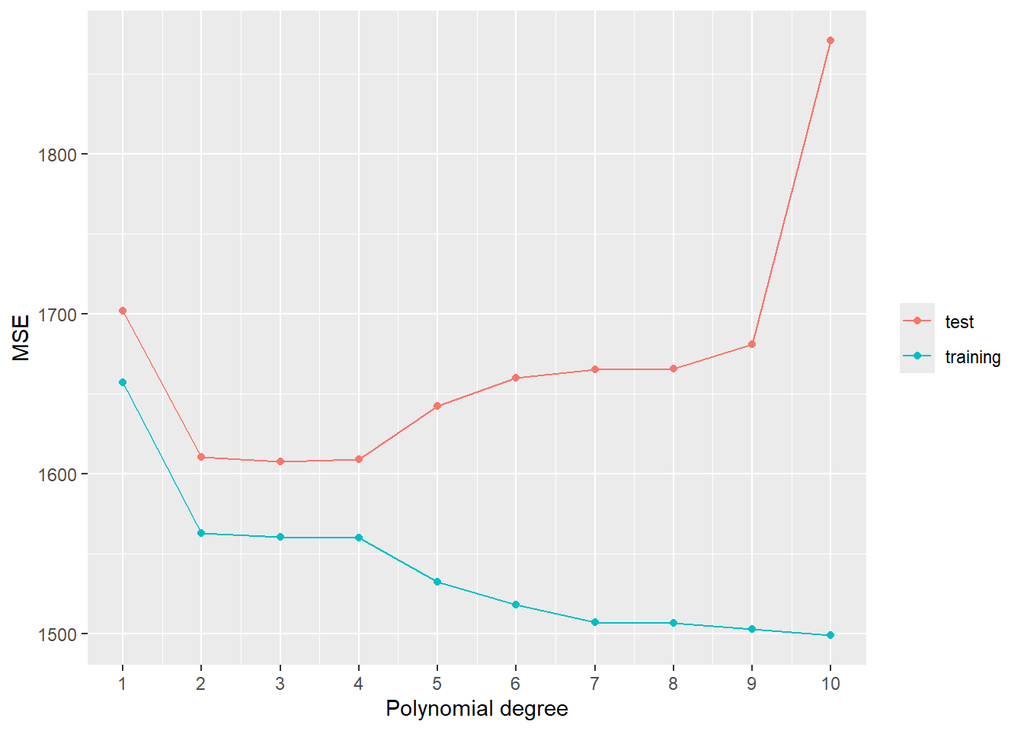

```r
errors_long <- errors %>%
  pivot_longer(c(training, test), names_to = "set", values_to = "mse")

ggplot(errors_long, aes(degree, mse, color = set)) +
  geom_line() +
  geom_point() +
  scale_x_continuous(breaks = 1:10) +
  labs(x = "Polynomial degree", y = "MSE", color = NULL)
```

*Does training MSE ever go up? Which degree has the lowest test MSE? Describe the degree-10 model.*

## Part 3: Make Bias and Variance Yourself

### Task 3.1: The simulated world

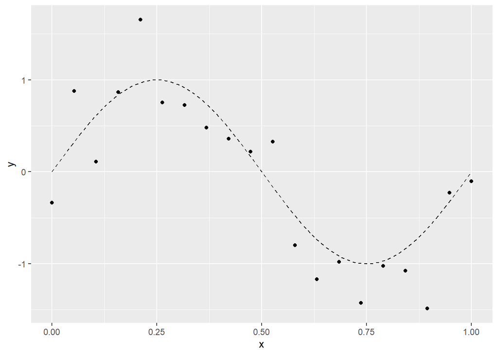

```r
f_true <- function(x) sin(2 * pi * x)

draw_training_set <- function(n = 20) {
  x <- seq(0, 1, length.out = n)
  tibble(x = x, y = f_true(x) + rnorm(n, mean = 0, sd = 0.4))
}

set.seed(5)   # seed added in the key only, so its numbers are reproducible
one_set <- draw_training_set()
ggplot(one_set, aes(x, y)) +
  geom_point() +
  geom_function(fun = f_true, linetype = "dashed")
```

### Task 3.2: Five hundred training sets

```r
predict_at_quarter <- function(degree, n = 20) {
  train <- draw_training_set(n)
  fit <- lm(y ~ poly(x, degree), data = train)
  predict(fit, newdata = tibble(x = 0.25))
}

set.seed(122)
darts <- tibble(
  degree = rep(c(1, 10), each = 500),
  pred   = c(replicate(500, predict_at_quarter(1)),
             replicate(500, predict_at_quarter(10)))
)
```

```r
bv_20 <- darts %>%
  group_by(degree) %>%
  summarise(bias     = mean(pred) - f_true(0.25),
            variance = var(pred))
bv_20
```

```
## # A tibble: 2 × 3
##   degree      bias variance
##    <dbl>     <dbl>    <dbl>
## 1      1 -0.599      0.0131
## 2     10  0.000161   0.0767
```

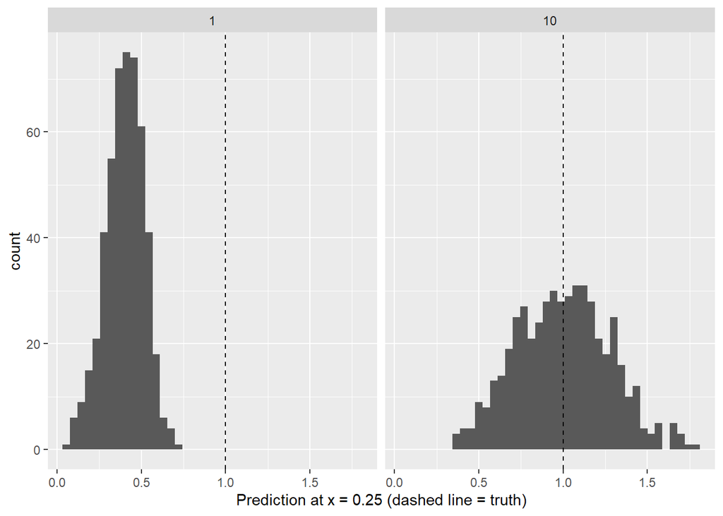

```r
ggplot(darts, aes(pred)) +
  geom_histogram(bins = 40) +
  geom_vline(xintercept = 1, linetype = "dashed") +
  facet_wrap(~ degree) +
  labs(x = "Prediction at x = 0.25 (dashed line = truth)")
```

*Which model has high bias (consistently off in the same direction)? Which has high variance (jumps around from one training set to the next)? Point to each in the histograms.*

- **Degree 1 has high bias.** Its histogram is centered around 0.4, a distance of 0.6 from the dashed line. Every training set produces roughly the same wrong answer.
- **Degree 10 has high variance.** Its histogram is centered almost on the line (bias essentially zero), but it is much wider: variance 0.077 versus 0.013, about 6 times as large. Which answer you get depends heavily on which training set you drew.

### Task 3.3: More data, again

```r
set.seed(122)
darts_200 <- tibble(
  degree = rep(c(1, 10), each = 500),
  pred   = c(replicate(500, predict_at_quarter(1,  n = 200)),
             replicate(500, predict_at_quarter(10, n = 200)))
)

bv_200 <- darts_200 %>%
  group_by(degree) %>%
  summarise(bias     = mean(pred) - f_true(0.25),
            variance = var(pred))
bv_200
```

```
## # A tibble: 2 × 3
##   degree     bias variance
##    <dbl>    <dbl>    <dbl>
## 1      1 -0.530    0.00136
## 2     10  0.00447  0.00682
```

*Which number did more data shrink? Which barely moved?*

|  | Bias, n = 20 | Bias, n = 200 | Variance, n = 20 | Variance, n = 200 |
| --- | --- | --- | --- | --- |
| Degree 1 | -0.599 | -0.53 | 0.0131 | 0.0014 |
| Degree 10 | 0 | 0.004 | 0.0767 | 0.0068 |

More data shrank **variance** for both models — by roughly a factor of 10, in line with 10 times the data. **Bias stayed put**: the straight line is still about 0.53 too low (the small change from 0.6 comes from spreading the x values differently, not from learning the curve), because a straight line can’t bend no matter how many points it sees.

## Wrap-up & Discussion

1. *“The degree-10 model had the lowest training MSE, so it’s the least biased model and the best one.”*

   **Right:** in this case, degree 10 does have low bias — in Part 3 its predictions were centered on the truth. **Wrong:** (a) low training MSE is not evidence of low bias; a model can get low training error by fitting noise, which is variance, not accuracy. (b) “Best” should be judged by test MSE, and degree 10 had by far the worst test MSE with 100 workers. Low bias doesn’t help if variance is enormous: expected test MSE is bias² **plus** variance plus irreducible error.
2. *200 customers, “use the most flexible method.”*

   With only 200 observations, a very flexible method is likely to have high variance — it will fit quirks of these 200 customers that don’t carry over to new ones (Tasks 2.1 and 3.2). Flexibility pays off only if it reduces bias by more than it adds variance, and with little data it usually doesn’t. Before trusting any model: hold out a test set (or use cross-validation) and compare candidates on **test** error, including a simple baseline. Choose the flexible method only if it actually wins there.

## Bonus (optional)

### Bonus 1: More wage data

```r
set.seed(313)
train_rows_big <- sample(nrow(Wage), 1500)
wage_train_big <- Wage[train_rows_big, ]
wage_test_big  <- Wage[-train_rows_big, ]

errors_big <- tibble(degree = 1:10, training = NA, test = NA)

for (d in 1:10) {
  fit <- lm(wage ~ poly(age, d), data = wage_train_big)
  errors_big$training[d] <- mse(wage_train_big$wage, predict(fit, newdata = wage_train_big))
  errors_big$test[d]     <- mse(wage_test_big$wage,  predict(fit, newdata = wage_test_big))
}

errors_big
```

```
## # A tibble: 10 × 3
##    degree training  test
##     <int>    <dbl> <dbl>
##  1      1    1671. 1678.
##  2      2    1600. 1597.
##  3      3    1592. 1594.
##  4      4    1590. 1593.
##  5      5    1589. 1593.
##  6      6    1587. 1593.
##  7      7    1586. 1592.
##  8      8    1586. 1594.
##  9      9    1585. 1593.
## 10     10    1585. 1596.
```

*How much worse is degree 10 than the best model now, compared to Part 2? Which did more data shrink here, bias or variance?*

With 100 training workers, degree 10’s test MSE was 263 above the best model’s. With 1,500 it is only 3.7 above — essentially no penalty. Degrees 2 through 10 are all within 4.7 of each other.

With 1,500 points spread across every age, any single worker has little pull on the fit, and there are enough points at every age to pin the curve down. The flexible model can no longer bend toward individual noisy observations, so its predictions stop swinging. In bias-variance terms, more data **shrank variance**, the same thing Task 3.3 showed in the simulation. Degree 10’s problem in Part 2 was variance, and 1,500 workers fixed it. A model whose problem is bias (like the straight line in Part 3) wouldn’t be rescued by more data.

### Bonus 2: One split, one answer?

*Why might a different seed give a different best degree?*

The test MSE is computed from one random split, so it is itself an estimate with noise: a different 100 training workers gives different fitted curves, and a different test set scores them differently. When several degrees (here 2-4) are within a few units of each other, the ranking among them can easily flip from split to split. Cross-validation (Day 14) averages over many splits to reduce this.